# Infant Mortality in NC

## Case Study 3: Infant Mortality Close to Home

Using data on births and infant deaths in North Carolina, we will obtain good estimates of infant mortality by subgroups of interest to the State.

## Case Study Data

- Vital records data on North Carolina births, 2011-2016
- Vital records data on North Carolina infant deaths of babies born 2011-2016

## Case Study Goals

Using data on NC births and infant deaths,

- obtain good estimates of the infant mortality rate by county, year, and race/ethnicity
- determine whether disparities in the infant mortality rate exist in NC as a function of race/ethnicity
- determine whether infant mortality rates, both overall and by group, are changing over time
- describe infant mortality rates and time trends by group in language accessible to policymakers
- make recommendations for where policymakers should invest resources to address infant mortality

## Case for Class: Infant Mortality

*Infant death* is defined as the death of a live-born infant during the first year of life.

The *infant mortality rate* is the number of infant deaths per 1000 live births. The infant mortality rate, which is relatively easily measured even in resource-poor settings, is often used as a marker of the overall health of a society because of the overlap in causes of infant mortality and factors that are likely to influence the health of an overall population, such as general living conditions, poverty and socioeconomic status, quality of medical care, and rates of illness. Infant mortality rates can be compared across different areas or across time to evaluate the impact of public health program or to determine where new investments in health are needed.

## Changes in US Infant Mortality over Time

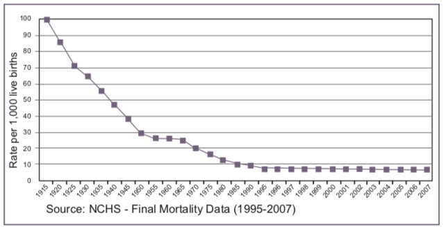

Infant Mortality in US, 1915-2007 (NCHS)

What do you think about the way the authors chose to display time in the plot?

## Disparities in Infant Mortality Rate

While overall infant mortality rates in the US have declined over time, major disparities in infant mortality rates exist, shown here as a function of race and ethnicity.

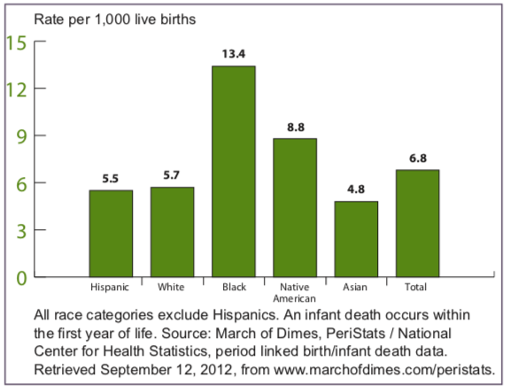

## NC Infant Mortality Rates as Presented by the State Center for Health Statistics

Take a look at the infant mortality data presented by the NC State Center for Health Statistics for 2015 at https://schs.dph.ncdhhs.gov/data/vital/ims/2015/2015rpt.html .

Do NC trends tend to mirror national trends by race/ethnicity?

How does this presentation of rates differ from that at https://schs.dph.ncdhhs.gov/data/vital/ims/2014/PCRandCountyRates.pdf, which is based on data from 2010-2014?

Which presentation would you recommend, and why?

## NC Data on Infant Mortality

These data are not in the public domain but are available on the Sakai website. Note the death data are not available on an individual record level but as counts broken down by year, county, and race/ethnicity.

## Add here plotting information across NC States

Infant mortality data can be visualized in number of interesting ways. [A nice tutorial by Luke Tierney at Iowa](https://homepage.divms.uiowa.edu/~luke/classes/STAT4580/maps.html#focusing-on-iowa) covers a variety of options.

For illustration, we’ll simulate data for North Carolina and plot it on the map.

## R code to link map and simulated data

```r
library(dplyr)
```

```r
library(ggplot2)
nc_map <- tbl_df(map_data("county", region = "north carolina"))
# Simulate data to plot by county
data_frame(
  subregion = unique(nc_map$subregion),
  simdata = sample(50:500, length(unique(nc_map$subregion)))
) -> simdata_df
# Join the values to the map
nc_map <- left_join(nc_map, simdata_df)
```

## Plotting code

```r
library(ggthemes); library(mapproj)
ggplot() +
  geom_polygon(data=nc_map, color="black",
               aes(x=long, y=lat, group=subregion, fill=simdata)) +
  viridis::scale_fill_viridis(name="Simulated Data ", direction=-1) +
  coord_map("polyconic") +
  ggthemes::theme_map() +
  theme(legend.position="bottom")
```

## Plot

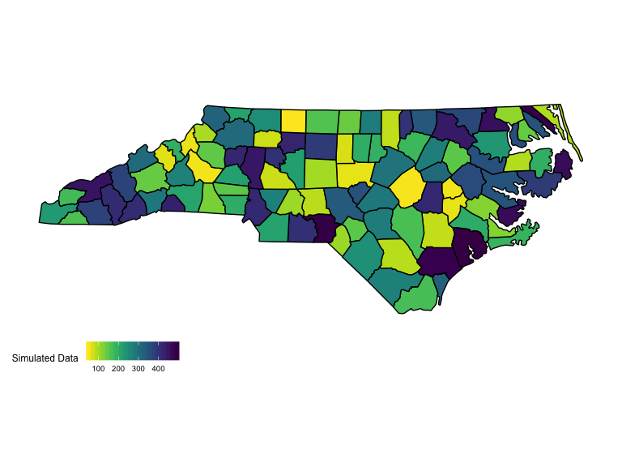